# Unit 4

Stuart Miller

January 26, 2020

## Load the Data

```r
Walmart = read.csv('./Walmart.csv',header = TRUE)
Stor9Item50 = Walmart %>% dplyr::filter(item == 50 & store == 9)
```

## Plots

Plot the realization, ACF, and spectral density.

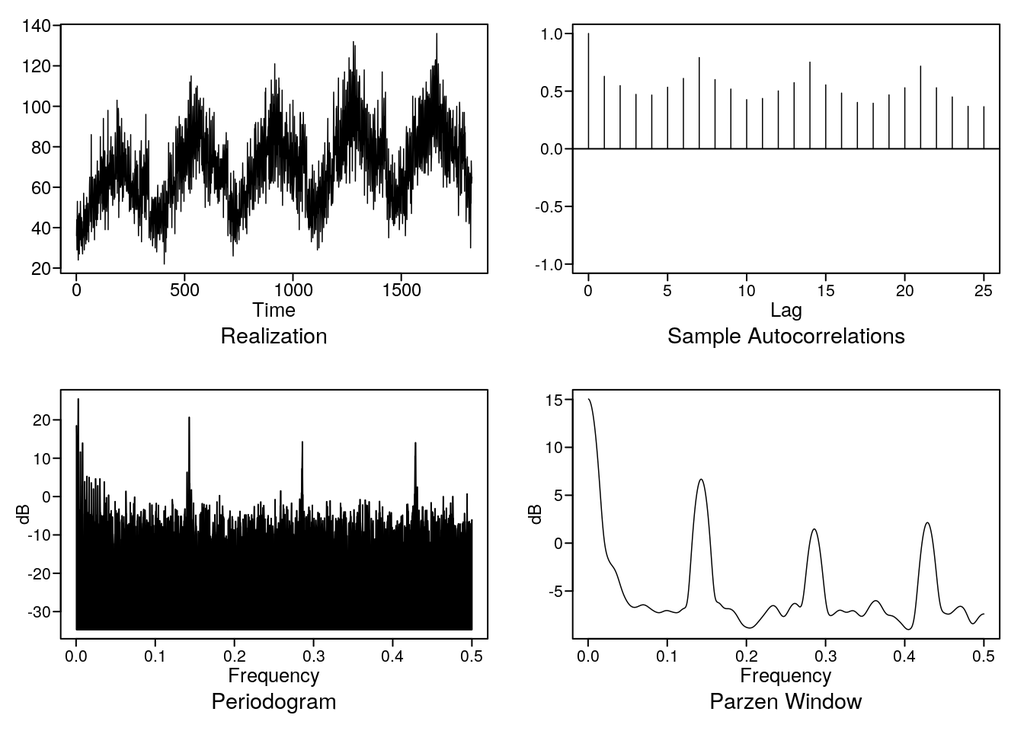

[output not shown]

[output cut: 545 more lines]

```r
plotts.sample.wge(Stor9Item50$sales)
```

## Suggested Completing Models

### Model 1

This model seems unlikely because, we would expect wandering behavior from this model. However, the realization appear to have oscillations and does not appear to be wandering.

Additionally, we would expect damped exponentals for the sample autocorrelations and only a peak at zero in the sample spectral density. These are not consistent with the sample autocorrelations and sample spectral density from the realization.

$$X_t - 0.967 X_t = a_t$$

```r
factor.wge(phi = c(0.967))
```

```
##
## Coefficients of Original polynomial:
## 0.9670
##
## Factor                 Roots                Abs Recip    System Freq
## 1-0.9670B              1.0341               0.9670       0.0000
##
##
```

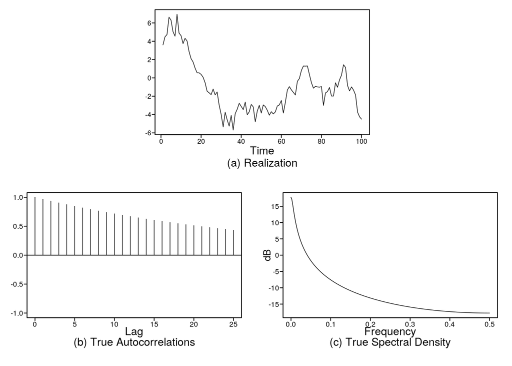

[output not shown]

[output cut: 75 more lines]

```r
plotts.true.wge(phi = c(0.967))
```

### Model 2

This model as frequencies at 0, 0.15, and 0.4, which is consistent with the sample spectral density of the walmart data. However, the wandering behavior (from the most dominate root) may be strong than what is exhibited in the walmart data.

$$X_t -1.452 X_{t-1} + 0.453 X_{t-2} + 0.294 X_{t-3} -0.175 X_{t-4} -0.237 X_{t-5} + 0.154 X_{t-6} = a_t$$

```r
factor.wge(phi = c(1.452, -0.453, -0.294, 0.175, 0.237, -0.154))
```

```
##
## Coefficients of Original polynomial:
## 1.4520 -0.4530 -0.2940 0.1750 0.2370 -0.1540
##
## Factor                 Roots                Abs Recip    System Freq
## 1-0.9428B              1.0607               0.9428       0.0000
## 1-0.9484B+0.6428B^2    0.7377+-1.0057i      0.8017       0.1493
## 1+1.0620B+0.4080B^2   -1.3014+-0.8702i      0.6388       0.4062
## 1-0.6228B              1.6057               0.6228       0.0000
##
##
```

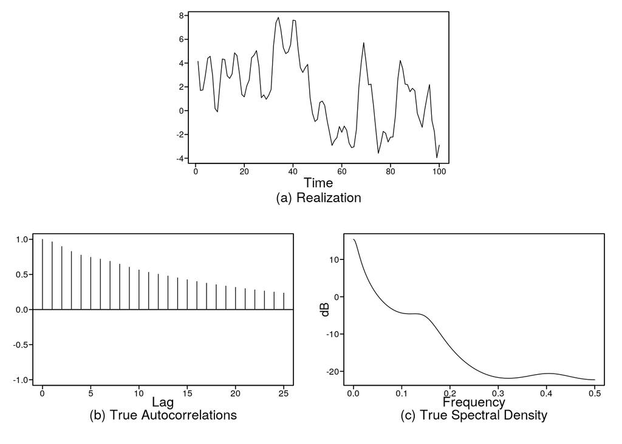

[output not shown]

[output cut: 75 more lines]

```r
plotts.true.wge(phi = c(1.452, -0.453, -0.294, 0.175, 0.237, -0.154))
```

### Model 3

This model has a root inside the unit circle, thus is not stationary. We will not consider this model because the AR analysis is insufficient.

$$X_t -1.445 X_{t-1} + 0.411 X_{t-2} + 0.038 X_{t-3} -0.170 X_{t-4} -0.362 X_{t-5} + 0.245 X_{t-6} + 0.177 X_{t-7} - 0.213 X_{t-8} = a_t$$

```r
factor.wge(phi = c(1.445, -0.411, -0.038, 0.170, 0.362, -0.245, -0.177, 0.213))
```

```
##
## Coefficients of Original polynomial:
## 1.4450 -0.4110 -0.0380 0.1700 0.3620 -0.2450 -0.1770 0.2130
##
## Factor                 Roots                Abs Recip    System Freq
## 1-1.2456B              0.8028               1.2456       0.0000
## 1-0.6653B+0.8160B^2    0.4077+-1.0292i      0.9033       0.1900
## 1+1.0631B+0.6139B^2   -0.8658+-0.9376i      0.7835       0.3687
## 1-1.2609B+0.5144B^2    1.2257+-0.6647i      0.7172       0.0791
## 1+0.6636B             -1.5069               0.6636       0.5000
##
##
```

### Model 4

The system frequencies of this model do not appear to be consistent with the sample spectral density plot of the walmart data. For instance, this model as a frequency at 0.074. We do not observe evidence of this frequency in the walmart data.

$$X_t - 1.384 X_{t-1} + 0.359 X_{t-2} + 0.309 X_{t-3} - 0.063 X_{t-4} - 0.317 X_{t-5} + 0.140 X_{t-6} + 0.0587 X_{t-7} + 0.199 X_{t-8} - 0.2877 X_{t-9} = a_t$$

```r
factor.wge(phi = c(1.384, -0.359, -0.309, 0.063, 0.317, -0.140, -0.0587, -0.199, 0.2877))
```

```
##
## Coefficients of Original polynomial:
## 1.3840 -0.3590 -0.3090 0.0630 0.3170 -0.1400 -0.0587 -0.1990 0.2877
##
## Factor                 Roots                Abs Recip    System Freq
## 1-0.9898B              1.0103               0.9898       0.0000
## 1-0.8851B+0.8545B^2    0.5179+-0.9497i      0.9244       0.1705
## 1-1.6496B+0.8498B^2    0.9706+-0.4845i      0.9218       0.0737
## 1+1.4991B+0.6791B^2   -1.1037+-0.5044i      0.8241       0.4318
## 1+0.6415B+0.5894B^2   -0.5442+-1.1834i      0.7677       0.3186
##
##
```

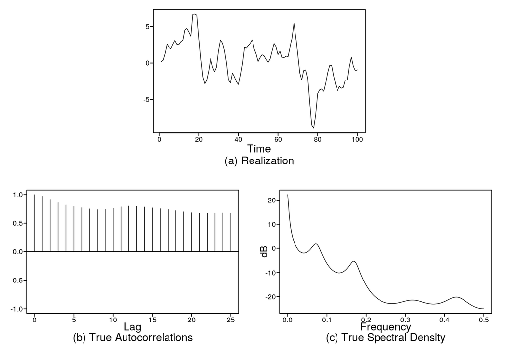

[output not shown]

[output cut: 75 more lines]

```r
plotts.true.wge(phi = c(1.384, -0.359, -0.309, 0.063, 0.317, -0.140, -0.0587, -0.199, 0.2877))
```